# Predicting correctness of exercise activity

## Data Processing and EDA

It was hypothesized that the user who performed the action should have little impacts on the motion data. PCA is performed to observe how well the data are partitioned linearly.

The data consisted of feature generated (eg skewness, kurtosis etc) from the raw sensor readings. Nonetheless, since they are absent in the test set, these generated features will be removed.

The number of observation is extremely sufficient comparing to the class and predictors. Moreover, NA is scarce after exclusion of generated features. Thus, only complete cases will be taken into model building.

```r
library(readr)
f <- 'https://d396qusza40orc.cloudfront.net/predmachlearn/pml-training.csv'
if(!exists("pml_training")){
  download.file(url = f, 'pml-training.csv')
  pml_training <- read_csv("pml-training.csv", col_types = cols(X1 = col_skip()))
}
#Data separated summary of each window
library(dplyr)
library(ggplot2)
library(ggpubr)
library(ggfortify)

prop_train <- pml_training[pml_training$new_window == 'no',]
table(prop_train$classe) #Rouhgly equal, 5 levels
```

```
##
##    A    B    C    D    E
## 5471 3718 3352 3147 3528
```

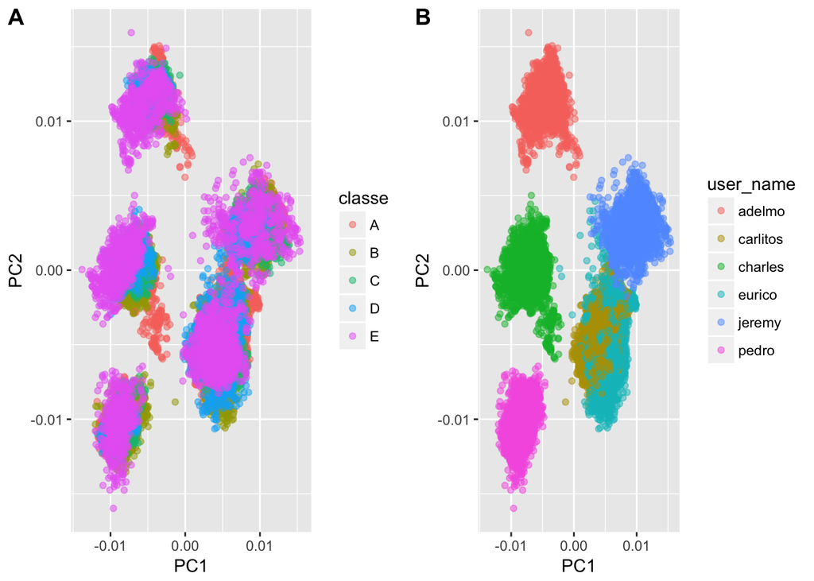

```r
keep <- (apply(pml_training, 2, function(x) sum(is.na(x))) < 1000)
prop_train <- select(prop_train, which(keep)) #Remove timestamp because of the format of test set
rmv <- which(apply(prop_train, 1, function(x)sum(is.na(x))) > 0) #Only 1 record has missing value in raw sensors.
prop_train <- prop_train[-rmv,]
pca <- prcomp(prop_train[,7:58], center = TRUE, scale = TRUE)
prop_train$user_name <- as.factor(prop_train$user_name)
prop_train$classe <- as.factor(prop_train$classe)

p1 <- autoplot(pca, data = prop_train, colour = 'classe', alpha = 0.5)
p2 <- autoplot(pca, data = prop_train, colour = 'user_name', alpha = 0.5)
ggarrange(p1, p2, labels = 'AUTO')
```

```r
#Interestingly and unfortunately, PCA distinguishes users who performed the action but not the classe
#This neccessitates include user_name in prediction model
```

Interestingly and unfortunately, PCA distinguished users who performed the action, but not the class. This neccssitates including user_name in model construction.

## Model building strategy

Three models are considered:

```
1   LDA
2   Tree-based
3   Random Forest
```

LDA would require adequate preprocessing as shown in code. Near-zero variance predictors are screened.

```r
library(caret)
set.seed(5)
key <- createDataPartition(prop_train$classe, p = 0.8, list = FALSE)
#Add partioning here
traintrain <- prop_train[key,-(2:6)]
estoob <- prop_train[-key,-(2:6)]
nzv <- nearZeroVar(traintrain, saveMetrics = TRUE)

cv <- trainControl(method = "cv", p = 0.75, number = 4)
#train
fit_tree <- train(classe ~ ., method = "rpart", trControl = cv, data = traintrain)
fit_lda <- train(classe~., preProcess = c('center', 'scale'), method = 'lda', data = traintrain)
fit_rf <- train(classe~., method = "rf", trControl = cv,data = traintrain)
```

## Validation

Predicting out-of-bag samples, the random forest models provide an accuracy of 0.9935 (95%CI 0.9904-0.9958).

```r
library(caret)
#predict
pred_tree <- predict(fit_tree, estoob)
pred_lda <- predict(fit_lda, estoob)
pred_rf <- predict(fit_rf, estoob)
#test
confusionMatrix(pred_tree, estoob$classe)
```

```
## Confusion Matrix and Statistics
##
##           Reference
## Prediction   A   B   C   D   E
##          A 999 302 316 284  88
##          B  23 257  17 100 100
##          C  70 184 337 245 194
##          D   0   0   0   0   0
##          E   2   0   0   0 323
##
## Overall Statistics
##
##                Accuracy : 0.4988
##                  95% CI : (0.4829, 0.5148)
##     No Information Rate : 0.2848
##     P-Value [Acc > NIR] : < 2.2e-16
##
##                   Kappa : 0.345
##  Mcnemar's Test P-Value : NA
##
## Statistics by Class:
##
##                      Class: A Class: B Class: C Class: D Class: E
## Sensitivity            0.9132  0.34590  0.50299   0.0000  0.45816
## Specificity            0.6396  0.92253  0.78146   1.0000  0.99936
## Pos Pred Value         0.5023  0.51710  0.32718      NaN  0.99385
## Neg Pred Value         0.9487  0.85467  0.88154   0.8362  0.89135
## Prevalence             0.2848  0.19344  0.17443   0.1638  0.18355
## Detection Rate         0.2601  0.06691  0.08774   0.0000  0.08409
## Detection Prevalence   0.5178  0.12939  0.26816   0.0000  0.08461
## Balanced Accuracy      0.7764  0.63421  0.64222   0.5000  0.72876
```

```r
confusionMatrix(pred_lda, estoob$classe)
```

```
## Confusion Matrix and Statistics
##
##           Reference
## Prediction   A   B   C   D   E
##          A 908 122  76  42  16
##          B  32 469  53  21  95
##          C  86  88 439  64  70
##          D  68  24  92 490  55
##          E   0  40  10  12 469
##
## Overall Statistics
##
##                Accuracy : 0.7225
##                  95% CI : (0.708, 0.7366)
##     No Information Rate : 0.2848
##     P-Value [Acc > NIR] : < 2.2e-16
##
##                   Kappa : 0.6485
##  Mcnemar's Test P-Value : < 2.2e-16
##
## Statistics by Class:
##
##                      Class: A Class: B Class: C Class: D Class: E
## Sensitivity            0.8300   0.6312   0.6552   0.7790   0.6652
## Specificity            0.9068   0.9351   0.9029   0.9256   0.9802
## Pos Pred Value         0.7801   0.7000   0.5877   0.6722   0.8832
## Neg Pred Value         0.9305   0.9136   0.9253   0.9553   0.9287
## Prevalence             0.2848   0.1934   0.1744   0.1638   0.1835
## Detection Rate         0.2364   0.1221   0.1143   0.1276   0.1221
## Detection Prevalence   0.3030   0.1744   0.1945   0.1898   0.1382
## Balanced Accuracy      0.8684   0.7832   0.7790   0.8523   0.8227
```

```r
confusionMatrix(pred_rf, estoob$classe)
```

```
## Confusion Matrix and Statistics
##
##           Reference
## Prediction    A    B    C    D    E
##          A 1090    5    0    0    0
##          B    3  737    4    0    1
##          C    0    1  665    6    3
##          D    0    0    1  623    0
##          E    1    0    0    0  701
##
## Overall Statistics
##
##                Accuracy : 0.9935
##                  95% CI : (0.9904, 0.9958)
##     No Information Rate : 0.2848
##     P-Value [Acc > NIR] : < 2.2e-16
##
##                   Kappa : 0.9918
##  Mcnemar's Test P-Value : NA
##
## Statistics by Class:
##
##                      Class: A Class: B Class: C Class: D Class: E
## Sensitivity            0.9963   0.9919   0.9925   0.9905   0.9943
## Specificity            0.9982   0.9974   0.9968   0.9997   0.9997
## Pos Pred Value         0.9954   0.9893   0.9852   0.9984   0.9986
## Neg Pred Value         0.9985   0.9981   0.9984   0.9981   0.9987
## Prevalence             0.2848   0.1934   0.1744   0.1638   0.1835
## Detection Rate         0.2838   0.1919   0.1731   0.1622   0.1825
## Detection Prevalence   0.2851   0.1940   0.1757   0.1625   0.1828
## Balanced Accuracy      0.9973   0.9947   0.9947   0.9951   0.9970
```

```r
library(randomForest)
```

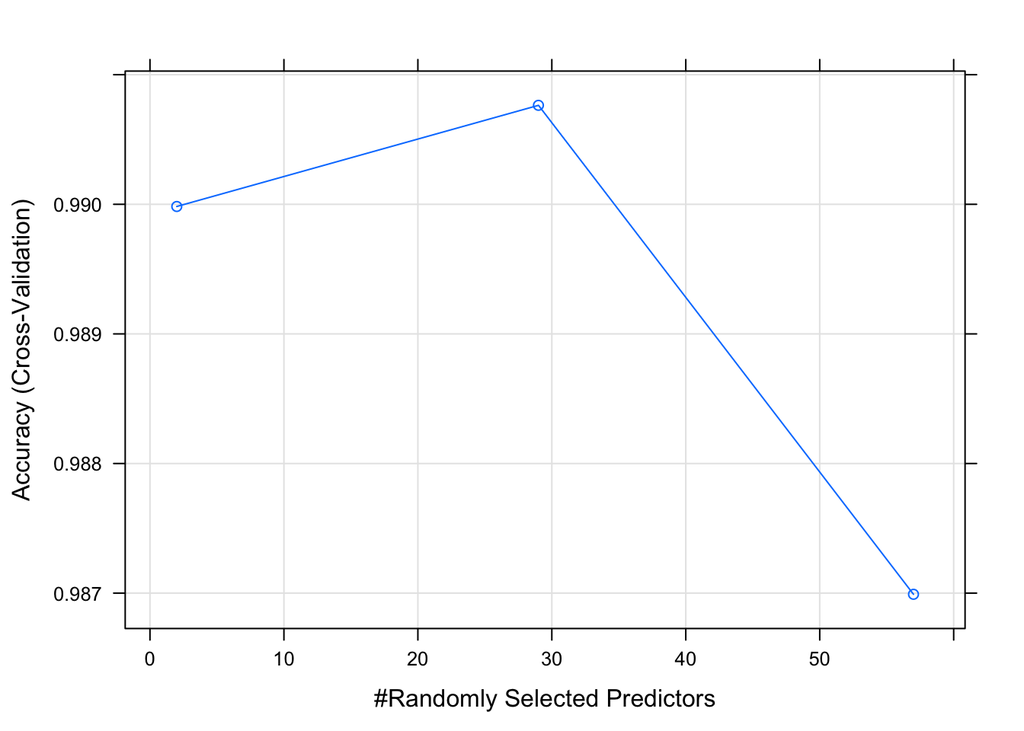

```r
plot(fit_rf)
```

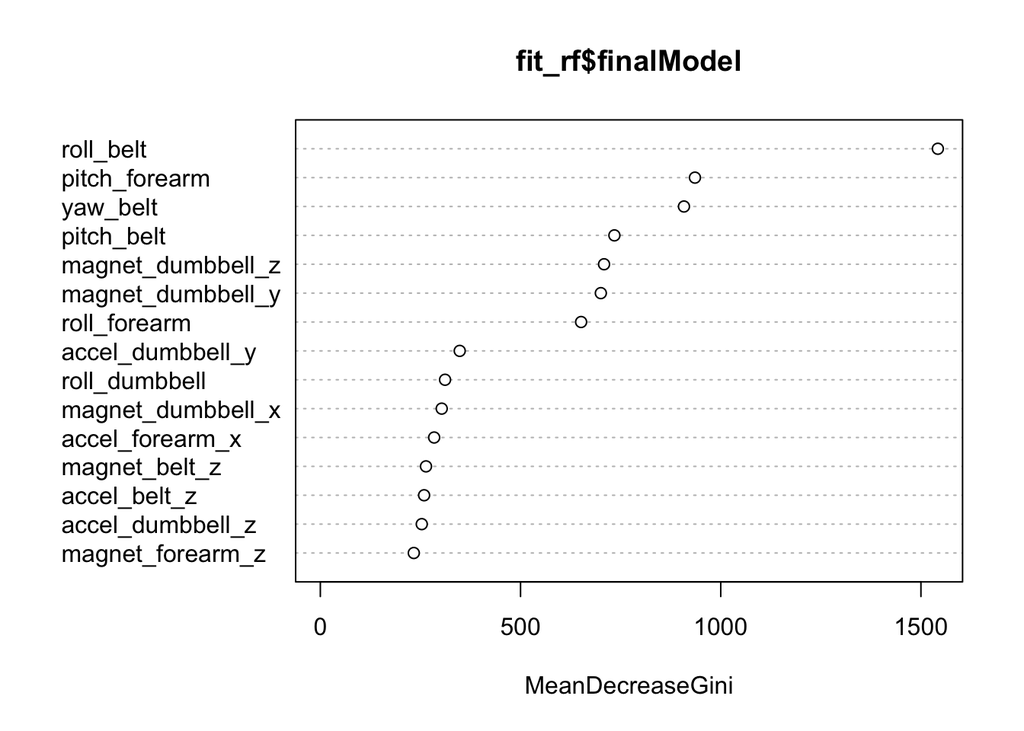

```r
varImpPlot(fit_rf$finalModel, n.var = 15)
```

## Predicting test set

Due to the excellent accuracy using random forest, we don’t see the need of model ensemble.

```r
library(readr)
pml_testing <- read_csv("pml-testing.csv", col_types = cols(X1 = col_skip()))
predict(fit_rf, pml_testing)
```

```
##  [1] B A B A A E D B A A B C B A E E A B B B
## Levels: A B C D E
```